# Covid-19 and Masks

Elizabeth Click

12/19/2020

```r
#getwd()
```

```r
#install.packages("cdlTools") for FIPS numbers
library(tidyverse)
library(lubridate)
library(cdlTools)
library(BSDA)
```

#### Question: Does mask use affect rate of cases or rate of deaths due to covid?

#### H_null: probability of new covid cases and deaths is not associated with mask usage, i.e. p_highcompliance = p_lowcompliance for new cases and new deaths.

#### H_alpha: probability of covid cases and deaths is associated with mask usage, i.e. p_highcompliance is not equal to p_lowcompliance

##### Alpha is set at 0.05.

Data Used: Dynata, T. N. (2020, July). Estimates from The New York Times, based on roughly 250,000 interviews conducted by Dynata from July 2 to July 14. Retrieved from https://github.com: https://github.com/nytimes/covid-19-data/tree/master/mask-use;

```r
maskuse <- read_csv("C:/Users/libcl/OneDrive/Documents/DATA110/NYTimesMaskWearing.csv")
census2019 <- read.csv("C:/Users/libcl/OneDrive/Documents/DATA110/Co_est_census_2019.csv")
covid <- read_csv("C:/Users/libcl/OneDrive/Documents/OxfordData11_30.csv")
```

#### Maskuse Dataset: clean and translate fips code to add variable for state name. Then select countypop2019 in census dataset to create totals for each state, so we can join with Maskuse dataset to do a weighted average of each states’ mask data

```r
#clean maskuse and census datasets
#change column heading to lower case
names(maskuse) <- tolower(names(maskuse))
names(census2019) <- tolower(names(census2019))
#drop last 3 digits of countyfp to get state fip
x <- as.integer(maskuse$countyfp)
statefp <- floor(x/1000)
#convert state fips code to state name
maskuse <- maskuse %>%
  mutate(regionname = fips(statefp, to="Name"))
#write.csv(maskuse, "C:/Users/libcl/OneDrive/Documents/MyNYTimesMaskUseSurvey.csv", row.names = FALSE)


#select population estimate for 2019 to be able to join by FIPS code
census2019 <- census2019 %>%
  summarize(stname, countyfp = state*1000 + county, state, county, popestimate2019)
#join by FIPS code
masks <- maskuse %>% left_join(census2019, by = "countyfp")
#write.csv(census2019, "C:/Users/libcl/OneDrive/Documents/MyCensus2019CountyFIPS.csv", row.names = FALSE)


#clean covid dataset
#change column heading to lower case
names(covid) <- tolower(names(covid))
#replace . with _ in column headings
names(covid) <- gsub(".","_",names(covid), fixed = TRUE)
names(covid) <- gsub(" ","_",names(covid), fixed = TRUE)

#write.csv(covid, "C:/Users/libcl/OneDrive/Documents/MyOxfordUSCovid.csv", row.names = FALSE)
```

```r
#sum masks column by state into new column, state_pop
#mutate weighted county average of compliance categories into st_* new names

masks <- masks %>%
  group_by(regionname) %>%
  mutate(state_pop = sum(popestimate2019))

masks <- masks %>%
  group_by(regionname) %>%
  mutate(st_never = never*popestimate2019/state_pop, st_rarely = rarely*popestimate2019/state_pop, st_sometimes = sometimes*popestimate2019/state_pop, st_frequently = frequently*popestimate2019/state_pop, st_always = always*popestimate2019/state_pop)

# get a county score to use instead of 5 categories; give it a 100 index score to average for each state in the next chunk. 0*rarely, 25*rarely, 50*sometimes, 70*frequently, 100*always. then add across to score each county

masks <- masks %>%
  group_by(regionname) %>%
  mutate(score = 0*never + 25*rarely + 50*sometimes + 75*frequently + 100*always)
summary(masks)
```

```
##     countyfp         never             rarely          sometimes
##  Min.   : 1001   Min.   :0.00000   Min.   :0.00000   Min.   :0.0010
##  1st Qu.:18178   1st Qu.:0.03400   1st Qu.:0.04000   1st Qu.:0.0790
##  Median :29176   Median :0.06800   Median :0.07300   Median :0.1150
##  Mean   :30384   Mean   :0.07994   Mean   :0.08292   Mean   :0.1213
##  3rd Qu.:45081   3rd Qu.:0.11300   3rd Qu.:0.11500   3rd Qu.:0.1560
##  Max.   :56045   Max.   :0.43200   Max.   :0.38400   Max.   :0.4220
##    frequently         always        regionname           stname
##  Min.   :0.0290   Min.   :0.1150   Length:3142        Length:3142
##  1st Qu.:0.1640   1st Qu.:0.3932   Class :character   Class :character
##  Median :0.2040   Median :0.4970   Mode  :character   Mode  :character
##  Mean   :0.2077   Mean   :0.5081
##  3rd Qu.:0.2470   3rd Qu.:0.6138
##  Max.   :0.5490   Max.   :0.8890
##      state           county      popestimate2019      state_pop
##  Min.   : 1.00   Min.   :  1.0   Min.   :      86   Min.   :  578759
##  1st Qu.:18.00   1st Qu.: 35.0   1st Qu.:   10902   1st Qu.: 3155070
##  Median :29.00   Median : 79.0   Median :   25726   Median : 6045680
##  Mean   :30.28   Mean   :103.6   Mean   :  104468   Mean   : 8932447
##  3rd Qu.:45.00   3rd Qu.:133.0   3rd Qu.:   68073   3rd Qu.:10617423
##  Max.   :56.00   Max.   :840.0   Max.   :10039107   Max.   :39512223
##     st_never           st_rarely          st_sometimes
##  Min.   :0.0000000   Min.   :0.0000000   Min.   :4.700e-07
##  1st Qu.:0.0001108   1st Qu.:0.0001217   1st Qu.:2.119e-04
##  Median :0.0003244   Median :0.0003396   Median :5.397e-04
##  Mean   :0.0009059   Mean   :0.0009753   Mean   :1.522e-03
##  3rd Qu.:0.0008565   3rd Qu.:0.0008824   3rd Qu.:1.407e-03
##  Max.   :0.0317992   Max.   :0.0408248   Max.   :6.900e-02
##  st_frequently         st_always             score
##  Min.   :1.290e-06   Min.   :0.0000032   Min.   :35.83
##  1st Qu.:3.823e-04   1st Qu.:0.0008993   1st Qu.:67.05
##  Median :9.492e-04   Median :0.0021227   Median :74.79
##  Mean   :3.099e-03   Mean   :0.0097284   Mean   :74.53
##  3rd Qu.:2.518e-03   3rd Qu.:0.0059780   3rd Qu.:82.29
##  Max.   :1.640e-01   Max.   :0.7430000   Max.   :96.22
```

#### Finally, we can use our county score to get a state score stored in new variable st_score

```r
# get state score by summing county score then dividing by number of counties for each state
masks <- masks %>%
  group_by(regionname) %>%
  summarize(regionname, st_score = sum(score)/n())
```

#### View quartiles with boxplot

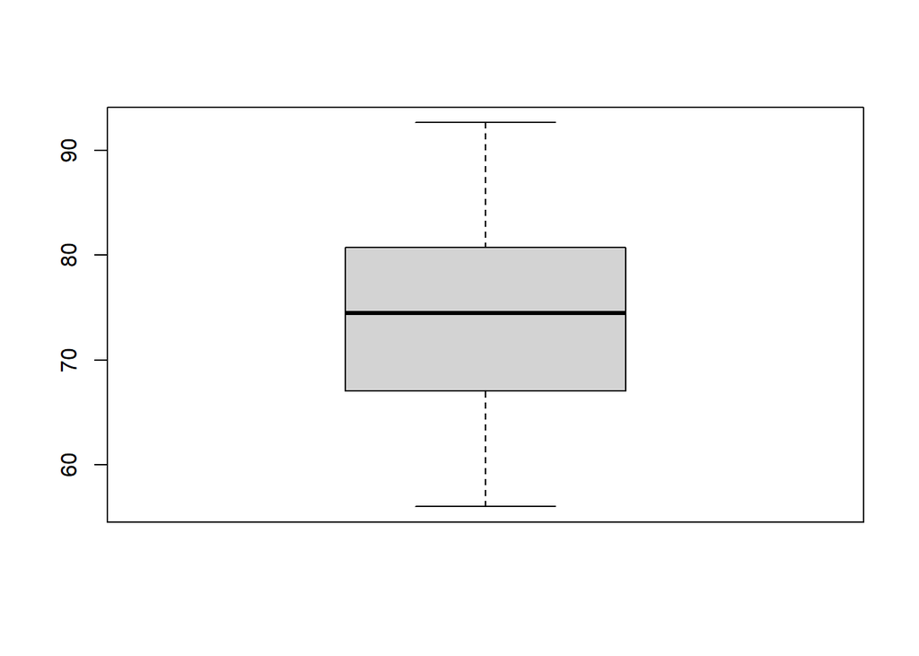

```r
#In later analysis we should filter regionname into 2 groups:st_score >= 82.29 and st_score <= 67.05 for 1st quartile and 3rd quartile from summary above and boxplot below for clearer mask compliance demarcation between states
p1 <- boxplot(masks$st_score)
```

#### Prepare to join covid dataset by first manipulating what columns and new variables we will need.

```r
#state only population data
population <- read_csv("C:/Users/libcl/OneDrive/Documents/DATA110/populationUSstates.csv")
#clean data
names(population) <- tolower(names(population))
names(population) <- gsub(".","_",names(population), fixed = TRUE)
names(population) <- gsub(" ","_",names(population), fixed = TRUE)

#write.csv(covid, "C:/Users/libcl/OneDrive/Documents/MyPopulation2018State.csv", row.names = FALSE)
```

#### Need to join population data to get comparisons of newdeaths and newcases per 100 by joining the covid and population datasets

```r
head(covid)
```

| countryname | countrycode | regionname | regioncode | jurisdiction | date | c1_school_closing | c1_flag | c1_notes | c2_workplace_closing | c2_flag | c2_notes | c3_cancel_public_events | c3_flag | c3_notes | c4_restrictions_on_gatherings | c4_flag | c4_notes | c5_close_public_transport | c5_flag | c5_notes | c6_stay_at_home_requirements | c6_flag | c6_notes | c7_restrictions_on_internal_movement | c7_flag | c7_notes | c8_international_travel_controls | c8_notes | e1_income_support | … |
| --- | --- | --- | --- | --- | --- | --- | --- | --- | --- | --- | --- | --- | --- | --- | --- | --- | --- | --- | --- | --- | --- | --- | --- | --- | --- | --- | --- | --- | --- | --- |
| United States | USA | NA | NA | NAT_GOV | 20200101 | 0 | NA | NA | 0 | NA | NA | 0 | NA | NA | 0 | NA | NA | 0 | NA | NA | 0 | NA | NA | 0 | NA | NA | 0 | NA | 0 | … |
| United States | USA | NA | NA | NAT_GOV | 20200102 | 0 | NA | NA | 0 | NA | NA | 0 | NA | NA | 0 | NA | NA | 0 | NA | NA | 0 | NA | NA | 0 | NA | NA | 0 | NA | 0 | … |
| United States | USA | NA | NA | NAT_GOV | 20200103 | 0 | NA | NA | 0 | NA | NA | 0 | NA | NA | 0 | NA | NA | 0 | NA | NA | 0 | NA | NA | 0 | NA | NA | 0 | NA | 0 | … |
| United States | USA | NA | NA | NAT_GOV | 20200104 | 0 | NA | NA | 0 | NA | NA | 0 | NA | NA | 0 | NA | NA | 0 | NA | NA | 0 | NA | NA | 0 | NA | NA | 0 | NA | 0 | … |
| United States | USA | NA | NA | NAT_GOV | 20200105 | 0 | NA | NA | 0 | NA | NA | 0 | NA | NA | 0 | NA | NA | 0 | NA | NA | 0 | NA | NA | 0 | NA | NA | 0 | NA | 0 | … |
| United States | USA | NA | NA | NAT_GOV | 20200106 | 0 | NA | NA | 0 | NA | NA | 0 | NA | NA | 0 | NA | NA | 0 | NA | NA | 0 | NA | NA | 0 | NA | NA | 0 | NA | 0 | … |

```r
covid1 <- covid %>%
  select(countryname, countrycode, regionname, date, confirmedcases, confirmeddeaths,  containmenthealthindexfordisplay,  economicsupportindexfordisplay)
head(covid1)
```

| countryname | countrycode | regionname | date | confirmedcases | confirmeddeaths | containmenthealthindexfordisplay | economicsupportindexfordisplay |
| --- | --- | --- | --- | --- | --- | --- | --- |
| United States | USA | NA | 20200101 | NA | NA | 0 | 0 |
| United States | USA | NA | 20200102 | NA | NA | 0 | 0 |
| United States | USA | NA | 20200103 | NA | NA | 0 | 0 |
| United States | USA | NA | 20200104 | NA | NA | 0 | 0 |
| United States | USA | NA | 20200105 | NA | NA | 0 | 0 |
| United States | USA | NA | 20200106 | NA | NA | 0 | 0 |

```r
covidpop <- right_join(covid1, population,
              by = c("regionname" = "state"))
```

#### Need to remove Puerto Rico and DC as data is not reported. Add new variable lub_date using lubridate package to transform date variable into class “date”. Then use lag on existing cumulative variables to add newcases and newdeaths variables which will give daily new cases and deaths added each day.

```r
covidpop <- covidpop %>%
  filter(!is.na(countrycode)) %>%   #remove puerto rico and dc and data not reported
  group_by(regionname) %>%
#add new variable lub_date of class date, and compute new cases and deaths.
    mutate(lub_date = ymd(date), newcases = confirmedcases - lag(confirmedcases), newdeaths = confirmeddeaths - lag(confirmeddeaths))
```

#### Get a rate per 100 people for newcases and newdeaths

```r
#use pop2018 to get a rate of for new cases and new deaths per 100 people
covidpop <- covidpop %>% #first drop calculated NAs
  drop_na(newcases)
covidpop <- covidpop %>%
  drop_na(newdeaths)

covidpop <- covidpop %>%
  filter(pop2018 != 0) %>%
    group_by(regionname) %>%
  summarize(regionname, lub_date, containmenthealthindexfordisplay, economicsupportindexfordisplay, confirmedcases, confirmeddeaths, newcases, newdeaths, pop2018, newcases_rate = newcases*100/pop2018, newdeaths_rate = newdeaths*100/pop2018)
```

#### set up data for binary variable of success and failure for newcases and newdeaths

```r
covidpop <- covidpop %>%
  mutate(status_cases = if_else(confirmedcases > lag(confirmedcases), "failure", "success"), status_deaths = if_else(confirmeddeaths > lag(confirmeddeaths), "failure", "success"))
```

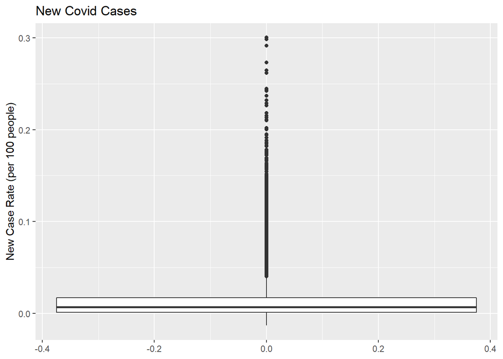

```r
 covidpop %>%
  ggplot() +
  geom_boxplot(aes(x = newcases_rate)) +
  xlab("New Case Rate (per 100 people)") +
  ggtitle("New Covid Cases") +
  coord_flip()
```

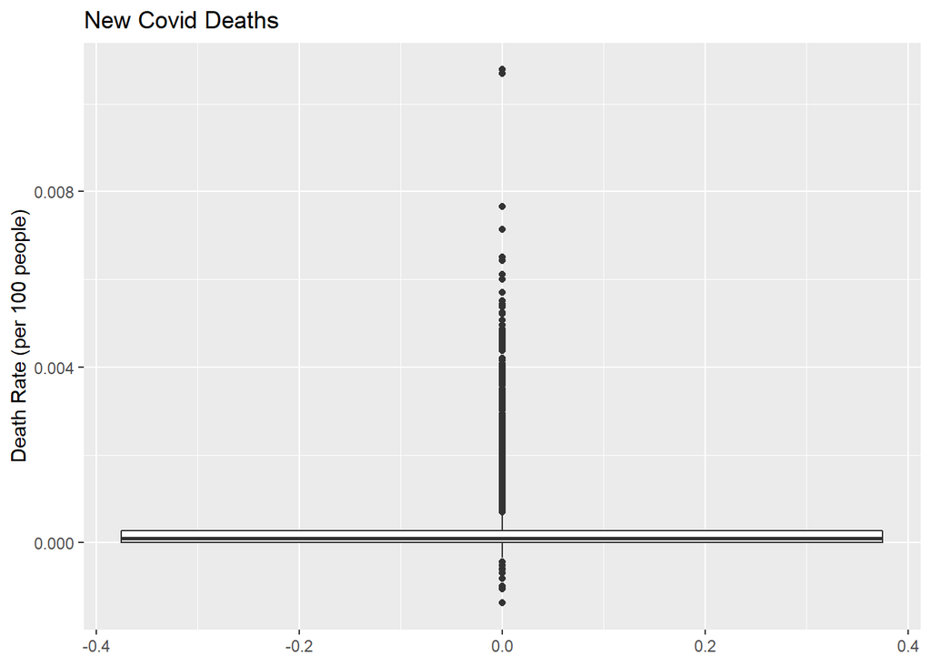

```r
covidpop %>%
  ggplot() +
  geom_boxplot(aes(x = newdeaths_rate)) +
  xlab("Death Rate (per 100 people)") +
  ggtitle("New Covid Deaths") +
  coord_flip()
```

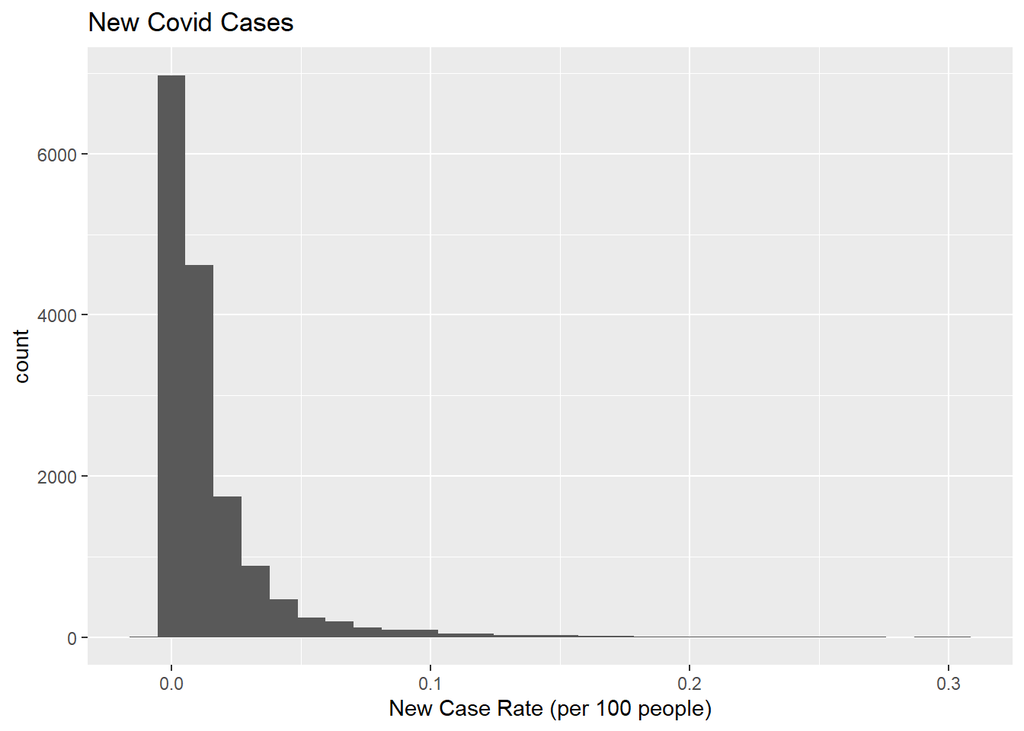

```r
covidpop %>%
  ggplot() +
  geom_histogram(aes(x = newcases_rate)) +
  xlab("New Case Rate (per 100 people)") +
  ggtitle("New Covid Cases")
```

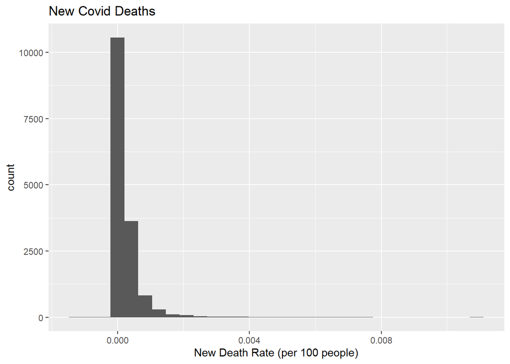

```r
covidpop %>%
  ggplot() +
  geom_histogram(aes(x = newdeaths_rate)) +
  xlab("New Death Rate (per 100 people)") +
  ggtitle("New Covid Deaths")
```

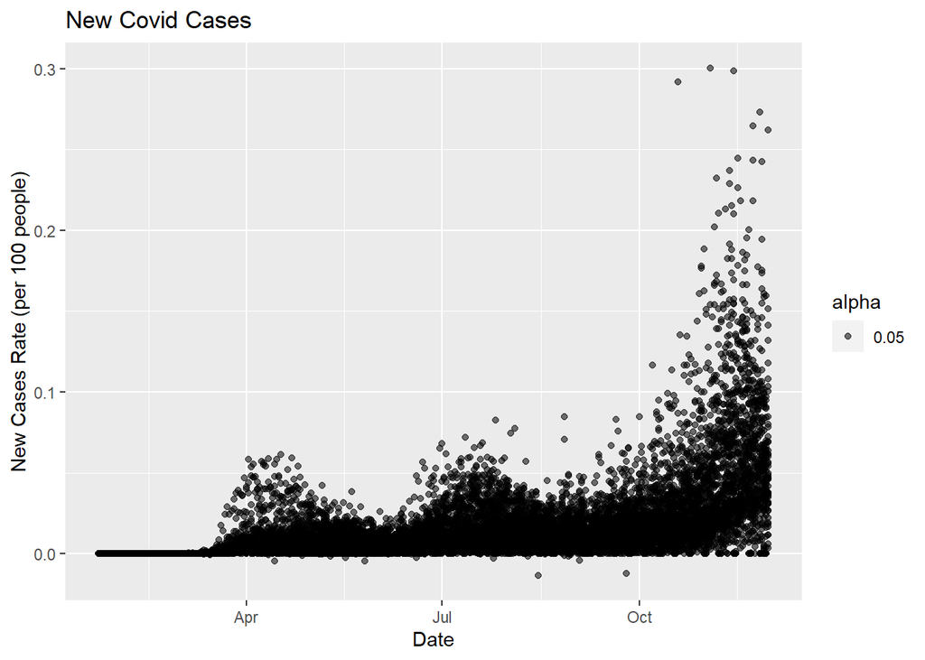

```r
covidpop %>%
  ggplot() +
  geom_point(aes(x = lub_date, y = newcases_rate, alpha = 0.05)) +
  xlab("Date") +
  ylab("New Cases Rate (per 100 people)") +
  ggtitle("New Covid Cases")
```

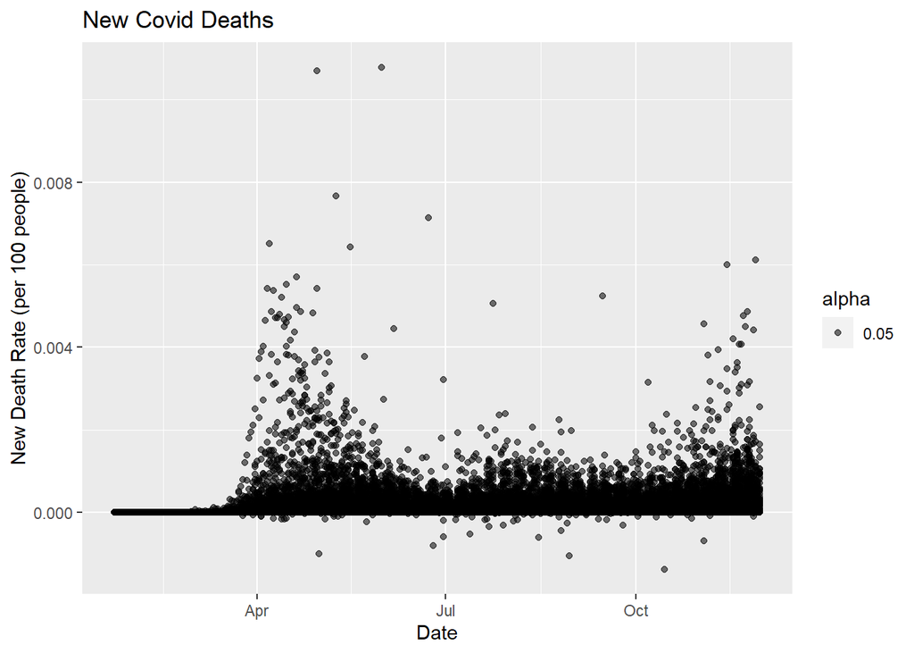

```r
covidpop %>%
  ggplot() +
  geom_point(aes(x = lub_date, y = newdeaths_rate, alpha = 0.05)) +
  xlab("Date") +
  ylab("New Death Rate (per 100 people)") +
  ggtitle("New Covid Deaths")
```

```r
fit_cases <- lm(newcases_rate~lub_date, data = covidpop)
fit_deaths <- lm(newdeaths_rate~lub_date, data = covidpop)
summary(fit_cases)
```

```
##
## Call:
## lm(formula = newcases_rate ~ lub_date, data = covidpop)
##
## Residuals:
##       Min        1Q    Median        3Q       Max
## -0.039228 -0.009511 -0.001381  0.004270  0.268024
##
## Coefficients:
##               Estimate Std. Error t value Pr(>|t|)
## (Intercept) -2.579e+00  3.175e-02  -81.24   <2e-16 ***
## lub_date     1.406e-04  1.722e-06   81.69   <2e-16 ***
## ---
## Signif. codes:  0 '***' 0.001 '**' 0.01 '*' 0.05 '.' 0.1 ' ' 1
##
## Residual standard error: 0.01946 on 15648 degrees of freedom
## Multiple R-squared:  0.299,  Adjusted R-squared:  0.2989
## F-statistic:  6674 on 1 and 15648 DF,  p-value: < 2.2e-16
```

```r
summary(fit_deaths)
```

```
##
## Call:
## lm(formula = newdeaths_rate ~ lub_date, data = covidpop)
##
## Residuals:
##        Min         1Q     Median         3Q        Max
## -0.0017083 -0.0001827 -0.0001142  0.0000159  0.0105700
##
## Coefficients:
##               Estimate Std. Error t value Pr(>|t|)
## (Intercept) -1.662e-02  7.536e-04  -22.05   <2e-16 ***
## lub_date     9.141e-07  4.087e-08   22.37   <2e-16 ***
## ---
## Signif. codes:  0 '***' 0.001 '**' 0.01 '*' 0.05 '.' 0.1 ' ' 1
##
## Residual standard error: 0.0004619 on 15648 degrees of freedom
## Multiple R-squared:  0.03099,    Adjusted R-squared:  0.03092
## F-statistic: 500.4 on 1 and 15648 DF,  p-value: < 2.2e-16
```

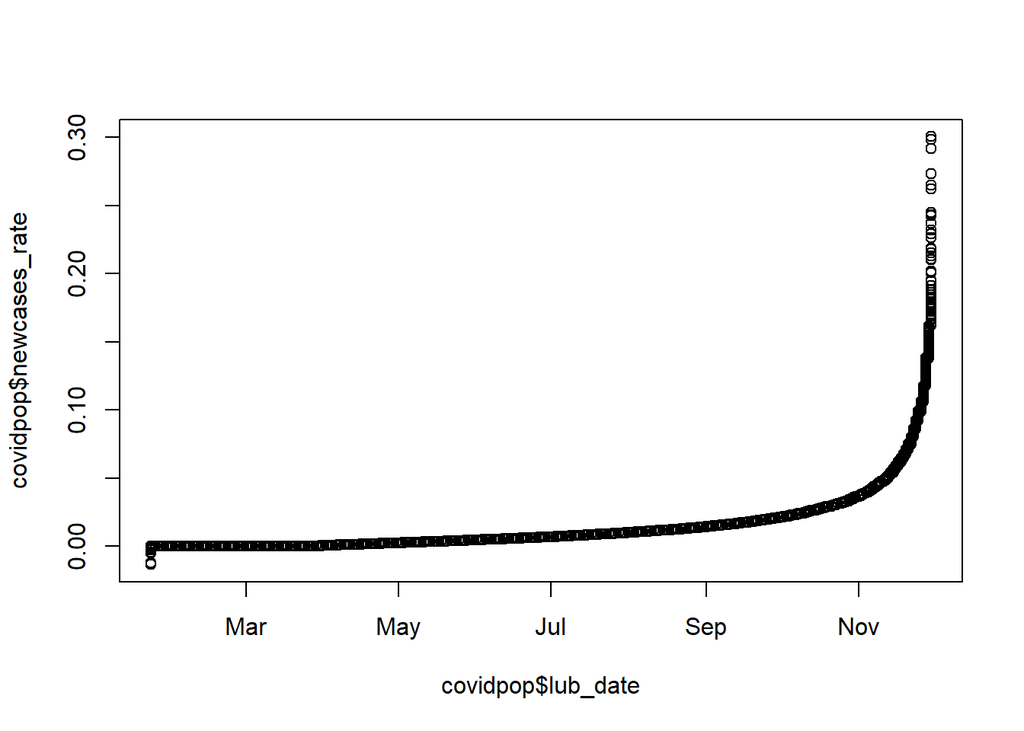

```r
qqplot(covidpop$lub_date, covidpop$newcases_rate)
```

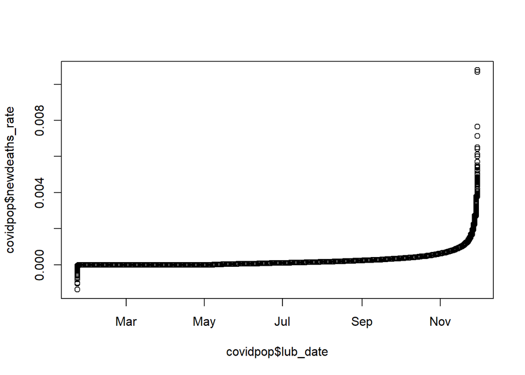

```r
qqplot(covidpop$lub_date, covidpop$newdeaths_rate)
```